# About me

## Statistician / Machine Learning specialist at Fred Hutch cancer center, Seattle.

## Consultant: currently accepting new projects!

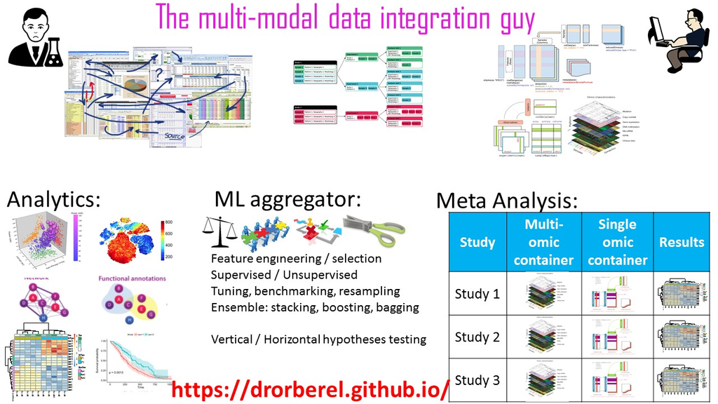

## Summary

Enthusiastic Statistician with expertise of implementing machine learning (resampling, ensemble, tuning, benchmarking) tools for high-dimensional multiplex data structure.  
Leveraging higher level scope tools for analysis of convoluted nested datasets, including multi-layer fusion data, n-table dimension reduction methods, and integration of multiple annotation domains.  
Expert at data engineering pipelines, utilizing scalable object-oriented tools.  
Designing analytical tools for complex nested experimental design, at the meta-analysis level.  
Over 15 years of experience in advanced R and Python.

## Skills

• Machine learning: Utilization of wide range of machine learning models, with a meta aggregator tools for high level scope analysis: tuning, benchmarking, ensemble, and resampling (cross-validation, bootstrap, etc.), including both specific model (xgboost, neural networks, etc.) and automotive multi-model tools.  
• Meta-analysis / high level scope tools: Exploiting accessors to nested datasets of non-atomic objects.  
• Object-oriented programing: Expertise in Bioconductor S4 object-oriented classes designed for multi-assay genomic data. Developed methods and workflows for convoluted data integration: Vertical / horizontal methods, gene-set-enrichment; meta-analysis.  
• Cross-programing language interface tools: Python’s scikit-learn, Spark, pandas, and others. Interface to R via reticulate rpy2 and others.  
• Git version control and reproducible research (Markdown). e.g. https://drorberel.github.io/  
• Web applications deployment via REST API and Shiny: e.g. https://dror.shinyapps.io/nomogram/  
• Developed R packages: Bioc2mlr https://github.com/drorberel/Bioc2mlr. Utility functions to transform Bioconductor’s S4 object oriented genomic classes into meta-aggregator machine learning packages (caret, mlr,…). Customized feature engineering pipelines in a composable ‘monad’ fashion. • Also familiar with BUGS / STAN, SAS, JMP, SPSS, Visual Basic, Java, Matlab, SQL, UNIX.  
• Longtime member of the American Statistician Association (ASA); Blogger; Active member at local meetup groups (R, data-science); Vice president of education at a Toastmasters club (International club for public speaking). Teaching applied statistics and machine learning at UW professional certificate program.

## Blog

https://medium.com/@drorberel

## Linkedin profile

https://www.linkedin.com/in/dror-berel-1848496/

## Publications

[https://www.ncbi.nlm.nih.gov/pubmed?term=%22Berel%20D%22[Author]](https://www.ncbi.nlm.nih.gov/pubmed?term=%22Berel%20D%22%5BAuthor%5D)